# Week 10 - Day 2 - Homework

### This is unfinished, I was mostly playing around to see what different code/

models would do. I understand regressions etc but think I have some confusion between models and the “long way” of doing things and have been trying to do all at once.

```r
library(mosaic)
```

# MVP

1. Load the `housing_prices.csv` data set and undertake an initial exploration of the data. You will find details on the data set on the relevant [Kaggle page](https://www.kaggle.com/camnugent/california-housing-prices)

```r
housing_prices <- read_csv("data/housing_prices.csv")
summary(housing_prices)
```

```
   longitude         latitude     housing_median_age  total_rooms    total_bedrooms     population
 Min.   :-124.3   Min.   :32.54   Min.   : 1.00      Min.   :    2   Min.   :   2.0   Min.   :    3
 1st Qu.:-121.8   1st Qu.:33.93   1st Qu.:18.00      1st Qu.: 1438   1st Qu.: 297.0   1st Qu.:  796
 Median :-118.5   Median :34.27   Median :28.00      Median : 2111   Median : 436.0   Median : 1179
 Mean   :-119.6   Mean   :35.65   Mean   :28.39      Mean   : 2620   Mean   : 539.6   Mean   : 1441
 3rd Qu.:-118.0   3rd Qu.:37.73   3rd Qu.:37.00      3rd Qu.: 3120   3rd Qu.: 648.0   3rd Qu.: 1746
 Max.   :-114.3   Max.   :41.95   Max.   :52.00      Max.   :39320   Max.   :6445.0   Max.   :35682
                                                                     NA's   :200
   households     median_income     median_house_value ocean_proximity
 Min.   :   2.0   Min.   : 0.4999   Min.   : 14999     Length:19675
 1st Qu.: 282.0   1st Qu.: 2.5268   1st Qu.:116600     Class :character
 Median : 411.0   Median : 3.4500   Median :173800     Mode  :character
 Mean   : 501.2   Mean   : 3.6767   Mean   :192478
 3rd Qu.: 606.0   3rd Qu.: 4.5826   3rd Qu.:248200
 Max.   :6082.0   Max.   :15.0001   Max.   :500000
```

```r
# 200 NAs in total_bedrooms. ALl numeric apart from ocean_proximity (chr)
```

2. We expect the `total_rooms` of houses to be strongly correlated with `total_bedrooms`. Use `ggpairs()` to investigate correlations between these two variables.

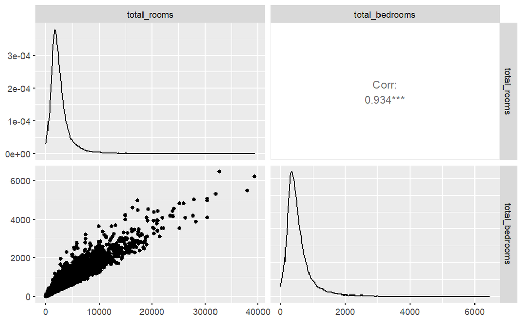

```r
housing_prices %>%
  select(total_rooms, total_bedrooms) %>%
  ggpairs()
```

3. So, we do find significant correlations. Let’s drop `total_bedrooms` from the dataset, and use only `total_rooms` going forward.

```r
housing_prices <- housing_prices %>%
  select(-total_bedrooms)
```

4. We are interested in developing a regression model for the `median_house_value` of a house in terms of the possible predictor variables in the dataset.
1. Use `ggpairs()` to investigate correlations between `median_house_value` and the predictors (this may take a while to run, don’t worry, make coffee or something).

[output not shown]

[output cut: 34 more lines]

[output not shown]

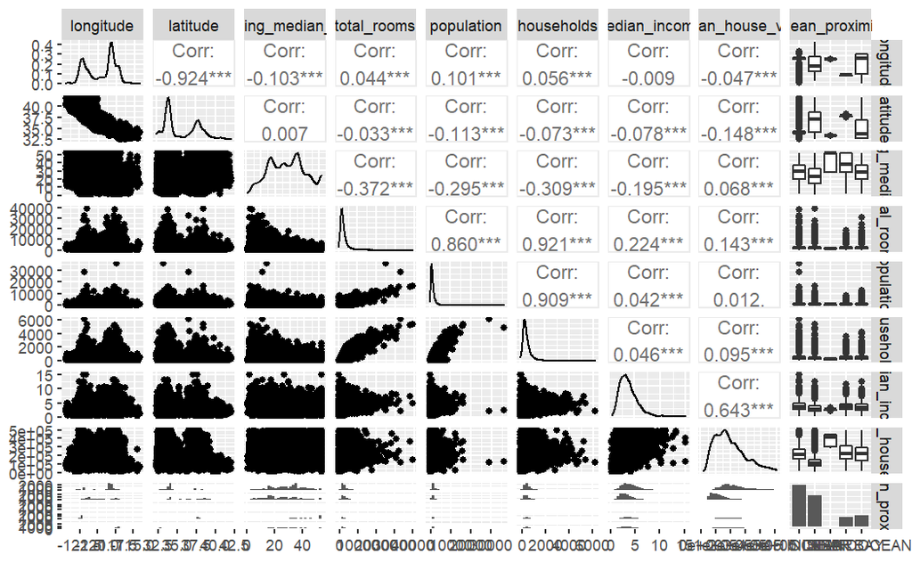

```r
# predictors are probably: housing_median_age (maybe income is better but I still
# think it could be interesting), total_rooms, population, households (maybe take
# out this or population, wait and see), median_income, ocean_proximity)
# took out lat and long as ocean_prox is probably ok

housing_prices %>%
  ggpairs()
```

```r
housing_prices
```

| longitude | latitude | housing_median_age | total_rooms | population | households | median_income | median_house_value | ocean_proximity |
| --- | --- | --- | --- | --- | --- | --- | --- | --- |
| -122.23 | 37.88 | 41 | 880 | 322 | 126 | 8.3252 | 452600 | NEAR BAY |
| -122.22 | 37.86 | 21 | 7099 | 2401 | 1138 | 8.3014 | 358500 | NEAR BAY |
| -122.24 | 37.85 | 52 | 1467 | 496 | 177 | 7.2574 | 352100 | NEAR BAY |
| -122.25 | 37.85 | 52 | 1274 | 558 | 219 | 5.6431 | 341300 | NEAR BAY |
| -122.25 | 37.85 | 52 | 1627 | 565 | 259 | 3.8462 | 342200 | NEAR BAY |
| -122.25 | 37.85 | 52 | 919 | 413 | 193 | 4.0368 | 269700 | NEAR BAY |
| -122.25 | 37.84 | 52 | 2535 | 1094 | 514 | 3.6591 | 299200 | NEAR BAY |
| -122.25 | 37.84 | 52 | 3104 | 1157 | 647 | 3.1200 | 241400 | NEAR BAY |
| -122.26 | 37.84 | 42 | 2555 | 1206 | 595 | 2.0804 | 226700 | NEAR BAY |
| -122.25 | 37.84 | 52 | 3549 | 1551 | 714 | 3.6912 | 261100 | NEAR BAY |

[output cut: 990 more lines]

2. Perform further `ggplot` visualisations of any significant correlations you find.

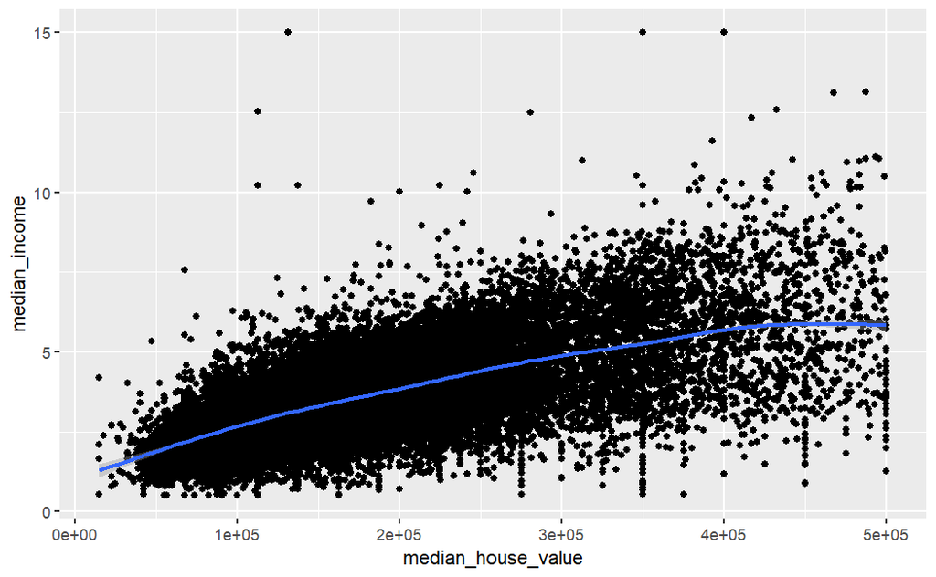

```r
# Population isn't significant but others are - is ocean_proximity?!

median_value_interest <- housing_prices %>%
  select(- population)

median_value_interest %>%
  ggplot()+
  aes(x = median_house_value,
      y = median_income)+
  geom_point() +
  geom_smooth()
```

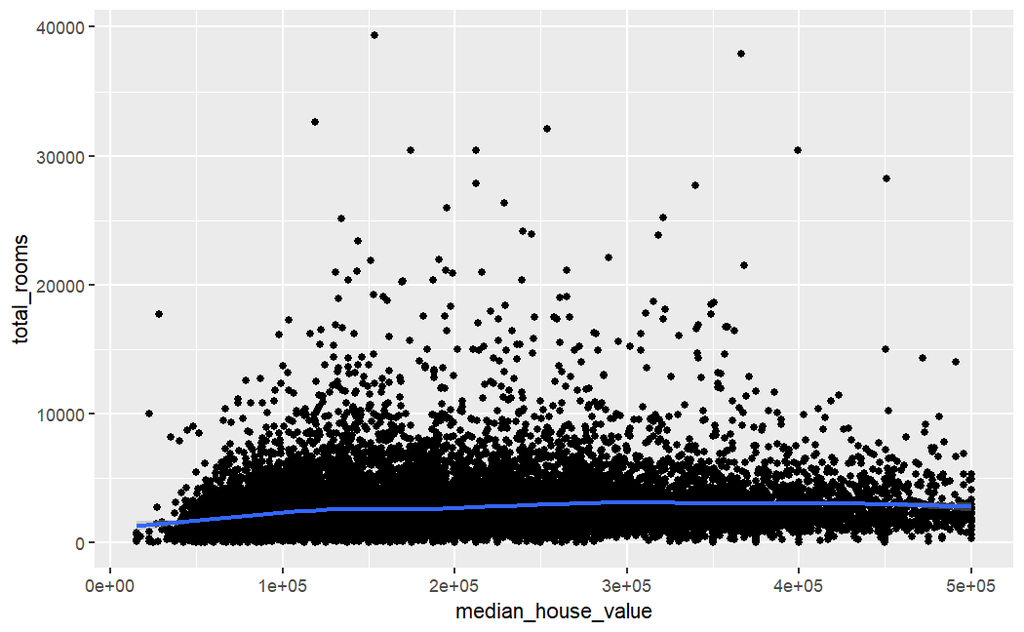

```r
median_value_interest %>%
  ggplot()+
  aes(x = median_house_value,
      y = total_rooms)+
  geom_point()+
  geom_smooth()
```

5. Shortly we may try a regression model to fit the categorical predictor `ocean_proximity`. Investigate the level of `ocean_proximity` predictors. How many dummy variables do you expect to get from it?

```r
housing_prices %>%
  distinct(ocean_proximity)
```

| ocean_proximity |
| --- |
| NEAR BAY |
| <1H OCEAN |
| INLAND |
| NEAR OCEAN |
| ISLAND |

6. Start with simple linear regression. Regress `median_house_value` on `median_income` and check the regression diagnostics.

```r
# dependent = house value as that is what is being studied
model <- lm(formula = median_house_value ~ median_income,
            data = housing_prices)
model
```

```
Call:
lm(formula = median_house_value ~ median_income, data = housing_prices)

Coefficients:
  (Intercept)  median_income
        45457          39987
```

```r
# intercept 45,457
summary(model)
```

```
Call:
lm(formula = median_house_value ~ median_income, data = housing_prices)

Residuals:
    Min      1Q  Median      3Q     Max
-513966  -51564  -13979   36549  403935

Coefficients:
              Estimate Std. Error t value Pr(>|t|)
(Intercept)    45457.0     1359.0   33.45   <2e-16 ***
median_income  39987.0      339.9  117.64   <2e-16 ***
---
Signif. codes:  0 ‘***’ 0.001 ‘**’ 0.01 ‘*’ 0.05 ‘.’ 0.1 ‘ ’ 1

Residual standard error: 74870 on 19673 degrees of freedom
Multiple R-squared:  0.4129,    Adjusted R-squared:  0.4129
F-statistic: 1.384e+04 on 1 and 19673 DF,  p-value: < 2.2e-16
```

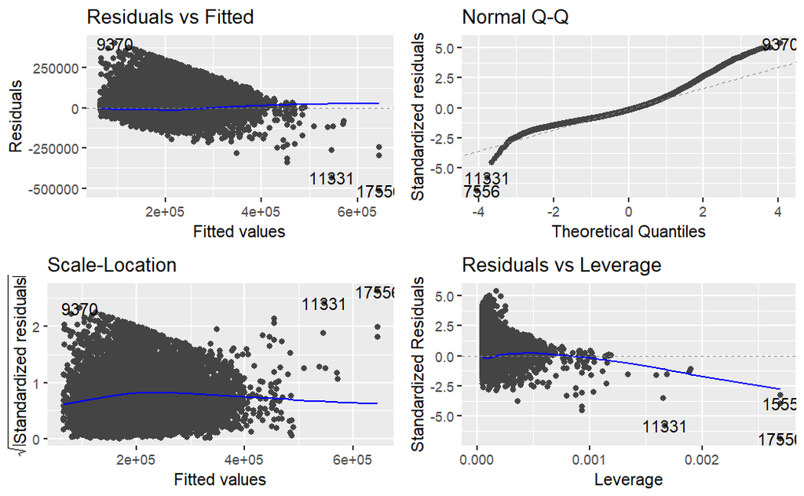

```r
library(modelr)
library(ggfortify) # need for autoplot

autoplot(model)
```

7. Add another predictor of your choice. Check your assumptions, diagnostics, and interpret the model.

```r
model2 <- lm(formula = median_house_value ~ median_income + ocean_proximity,
            data = housing_prices)


summary(model2)
```

```
Call:
lm(formula = median_house_value ~ median_income + ocean_proximity,
    data = housing_prices)

Residuals:
    Min      1Q  Median      3Q     Max
-479055  -41086  -11143   27912  376647

Coefficients:
                          Estimate Std. Error t value Pr(>|t|)
(Intercept)                83581.2     1407.7  59.373  < 2e-16 ***
median_income              35118.0      304.8 115.223  < 2e-16 ***
ocean_proximityINLAND     -72313.7     1100.7 -65.695  < 2e-16 ***
ocean_proximityISLAND     200480.2    29232.9   6.858 7.19e-12 ***
ocean_proximityNEAR BAY    16629.7     1591.9  10.446  < 2e-16 ***
ocean_proximityNEAR OCEAN  15552.9     1500.8  10.363  < 2e-16 ***
---
Signif. codes:  0 ‘***’ 0.001 ‘**’ 0.01 ‘*’ 0.05 ‘.’ 0.1 ‘ ’ 1

Residual standard error: 65340 on 19669 degrees of freedom
Multiple R-squared:  0.5529,    Adjusted R-squared:  0.5528
F-statistic:  4865 on 5 and 19669 DF,  p-value: < 2.2e-16
```

# Extension

8. Try adding an interaction between `log(medium_income)` and your chosen categorical predictor. Do you think this interaction term is statistically justified?
9. Find and plot an appropriate visualisation to show the effect of this interaction